# Example: Inspecting and Trimming Low-Quality Bases

## Loading necessary libraries

```r
library(BiocInstaller)
library(qrqc)
library(dplyr)
library(ggplot2)
```

## Initial preps

let’s trim the `untreated1_chr4.fq` FASTQ file. This FASTQ file was generated from the untreated1_chr4.bam BAM file in the pasillaBamSubset Bioconductor package. To keep things simple, we’ll use each program’s default settings. Starting with sickle:

```r
$ sickle se -f untreated1_chr4.fq -t sanger -o untreated1_chr4_sickle.fq
```

`sickle` takes an input file through -f, a quality type through -t, and trimmed output file with -o. Now, let’s run `seqtk trimfq`, which takes a single argument and outputs trimmed sequences through standard out:

```r
$ seqtk trimfq untreated1_chr4.fq > untreated1_chr4_trimfq.fq
```

## Visualisation comparison of results

Let’s compare these results in R. We’ll use `qrqc` to collect the distributions of quality by position in these files, and then visualize these using `ggplot2`. We could load these in one at a time, but a nice workflow is to automate this with `lapply()`:

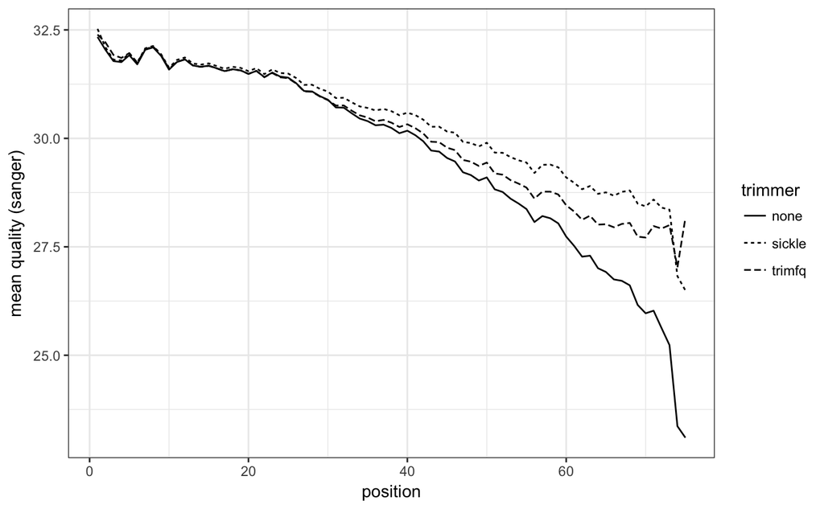

```r
# FASTQ files
fqfiles <- c(none="untreated1_chr4.fq",
            sickle="untreated1_chr4_sickle.fq",
            trimfq="untreated1_chr4_trimfq.fq")
# Load each file in, using qrqc's readSeqFile
# We only need qualities, so we turn off some of
# readSeqFile's other features.
seq_info <- lapply(fqfiles, function(file) {
                  readSeqFile(file, hash=FALSE, kmer=FALSE)
                  })
# Extract the qualities as dataframe, and append
# a column of which trimmer (or none) was used. This
# is used in later plots.
quals <- mapply(function(sfq, name) {
                  qs <- getQual(sfq)
                  qs$trimmer <- name
                  qs
                  }, seq_info, names(fqfiles), SIMPLIFY=FALSE)
# Combine separate dataframes in a list into single dataframe
d <- do.call(rbind, quals)
# Visualize qualities
p1 <- ggplot(d) + geom_line(aes(x=position, y=mean, linetype=trimmer))
p1 <- p1 + ylab("mean quality (sanger)") + theme_bw()
print(p1)
```

```r
# Use qrqc's qualPlot with list produces panel plots
# Only shows 10% to 90% quantiles and lowess curve
p2 <- qualPlot(seq_info, quartile.color=NULL, mean.color=NULL) + theme_bw()
```

```
Ignoring unknown aesthetics: y
```

```r
p2 <- p2 + scale_y_continuous("quality (sanger)")
```

[output not shown]

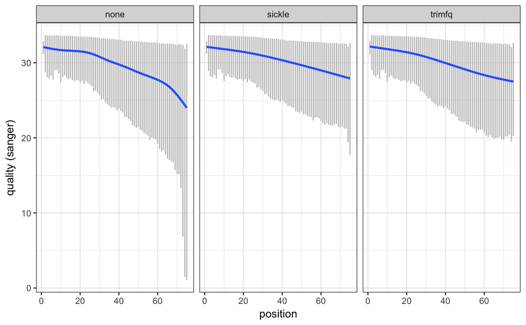

```r
print(p2)
```

In one line, we can trim low-quality bases from the ends of these sequences—running the trimming commands is not difficult. The more important step is to *visualize* what these trimming programs did to our data by comparing the files before and after trimming. Checking how programs change our data rather than trusting they did the right thing is an essential part of robust bioinformatics and abides by the Golden Rule (don’t trust your tools). In this example, checking a small subset of data took fewer than 20 lines of code (ignoring blank lines and comments that improve readability) and only a few extra minutes—but it gives us valuable insight in what these programs do to our data and how they differ. If we like, we could also run both quality trim‐ ming programs with numerous different settings and compare how these affect our results. Much of careful bioinformatics is this process: run a program, compare out‐ put to original data, run a program, compare output, and so on.